# Relatedness in a human GWAS cohort

A GWAS treats individuals as independent samples. If some of them are close relatives that assumption breaks: relatives share long stretches of genome, so they share genotypes at many SNPs at once, and the test statistics come out too large.

So before running an association study you check who is related to whom. This is a short exercise that does exactly that, on the same case/control cohort used in the GWAS exercises.

### How PLINK estimates relatedness

For every **pair** of individuals PLINK estimates how much of their genome they share *identical by descent* (IBD) - inherited from a common ancestor. It reports three numbers that sum to one:

|  | meaning |
| --- | --- |
| **Z0** | fraction of the genome where they share **0** alleles IBD |
| **Z1** | fraction where they share **1** allele IBD |
| **Z2** | fraction where they share **2** alleles IBD |

and it summarises them as

[figure not shown]

which is the expected proportion of alleles shared IBD - twice the kinship coefficient. The textbook expectations are:

| relationship | Z0 | Z1 | Z2 | PI_HAT |
| --- | --- | --- | --- | --- |
| the same person (or identical twins) | 0 | 0 | 1 | 1 |
| parent - offspring | 0 | 1 | 0 | 0.5 |
| full siblings | 0.25 | 0.5 | 0.25 | 0.5 |
| half sibs, uncle - nephew, grandparent | 0.5 | 0.5 | 0 | 0.25 |
| first cousins | 0.75 | 0.25 | 0 | 0.125 |
| unrelated | 1 | 0 | 0 | 0 |

> **An important assumption.** This estimator works from allele frequencies estimated in your sample, and it assumes everybody is drawn from **one homogeneous population**. If the sample instead contains several populations, individuals from the same population look "related" to each other simply because they share ancestry, and PI_HAT is inflated. That is fine for this data set, which is a single population - but it is the reason the same analysis on a structured sample needs a different method.

## 1. Setup

```
#############################################################
# ALL PATHS ARE SET HERE
# If the data moves, this is the ONLY cell you need to change.
#############################################################

# where the shared data lives
DATA=/course/data/current_data/gwas_human

# where you will do the exercise
WORK=$HOME/relatedness_human
mkdir -p $WORK
cd $WORK

cat > $WORK/env.sh <<EOF
export DATA=$DATA
export WORK=$WORK
cd $WORK
EOF

echo "working folder: $(pwd)"
echo
echo "the data is a PLINK binary fileset:"
ls -l $DATA
```

```
working folder: /davidData/data/course/.nbrender_home/relatedness_human

the data is a PLINK binary fileset:
total 58852
-rw-r-xr-- 1 albrecht admin 44434499 Sep 16 18:43 gwa.bed
-rw-r-xr-- 1 albrecht admin 15809874 Sep 16 18:43 gwa.bim
-rw-r-xr-- 1 albrecht admin     6792 Sep 16 18:43 gwa.fam
-rw-r-xr-- 1 albrecht admin     4656 Sep 16 18:43 pheno3.txt
```

### The data

The genotypes are in PLINK's binary format: `.bed` holds the genotypes, `.bim` the SNPs and `.fam` the individuals.

```
source ~/relatedness_human/env.sh

echo "individuals: $(wc -l < $DATA/gwa.fam)"
echo "SNPs:        $(wc -l < $DATA/gwa.bim)"

echo
echo "--- the last column of the .fam is the phenotype (1 = control, 2 = case) ---"
awk '{print $6}' $DATA/gwa.fam | sort | uniq -c

echo
echo "--- first lines of the .fam ---"
head -n 3 $DATA/gwa.fam
```

```
individuals: 356
SNPs:        499264

--- the last column of the .fam is the phenotype (1 = control, 2 = case) ---
    200 1
    156 2

--- first lines of the .fam ---
case1 1 0 0 1 2
case2 1 0 0 1 2
case3 1 0 0 2 2
```

**Questions**

- How many individuals and how many SNPs are there?
- How many pairs of individuals does that make? (that is how many relatedness estimates we are about to get)

## 2. Estimate relatedness

`--genome` does the pairwise IBD estimation. `--autosome` keeps only the autosomes, since the sex chromosomes do not behave like the rest of the genome, and `--maf 0.05` drops rare SNPs, whose frequencies are too poorly estimated to be useful here.

This takes a minute or two.

```
source ~/relatedness_human/env.sh
# ~1-2 min

plink --bfile $DATA/gwa --genome --autosome --maf 0.05 --out gwa_ibd

echo
echo "--- created files ---"
ls -l gwa_ibd.genome
```

```
PLINK v1.90b6 64-bit (26 May 2018)             www.cog-genomics.org/plink/1.9/
(C) 2005-2018 Shaun Purcell, Christopher Chang   GNU General Public License v3
Logging to gwa_ibd.log.
Options in effect:
  --autosome
  --bfile /course/data/current_data/gwas_human/gwa
  --genome
  --maf 0.05
  --out gwa_ibd

386830 MB RAM detected; reserving 193415 MB for main workspace.
488756 out of 499264 variants loaded from .bim file.
356 people (145 males, 211 females) loaded from .fam.
356 phenotype values loaded from .fam.
Using up to 87 threads (change this with --threads).
Before main variant filters, 356 founders and 0 nonfounders present.
Calculating allele frequencies... 0%1%2%3%4%5%6%7%8%9%10%11%12%13%14%15%16%17%18%19%20%21%22%23%24%25%26%27%28%29%30%31%32%33%34%35%36%37%38%39%40%41%42%43%44%45%46%47%48%49%50%51%52%53%54%55%56%57%58%59%60%61%62%63%64%65%66%67%68%69%70%71%72%73%74%75%76%77%78%79%80%81%82%83%84%85%86%87%88%89%90%91%…
Total genotyping rate is 0.964498.
111253 variants removed due to minor allele threshold(s)
(--maf/--max-maf/--mac/--max-mac).
377503 variants and 356 people pass filters and QC.
Among remaining phenotypes, 156 are cases and 200 are controls.
IBD calculations complete.
Finished writing gwa_ibd.genome .

--- created files ---
-rw-r--r-- 1 albrecht admin 6354957 Sep 16 19:45 gwa_ibd.genome
```

Have a look at the output. One line per pair of individuals.

```
source ~/relatedness_human/env.sh

echo "--- the columns ---"
head -n 1 gwa_ibd.genome

echo
echo "--- the first few pairs ---"
head -n 4 gwa_ibd.genome

echo
echo "--- number of pairs ---"
echo $(( $(wc -l < gwa_ibd.genome) - 1 ))
```

```
--- the columns ---
      FID1 IID1      FID2 IID2 RT    EZ      Z0      Z1      Z2  PI_HAT PHE       DST     PPC   RATIO

--- the first few pairs ---
      FID1 IID1      FID2 IID2 RT    EZ      Z0      Z1      Z2  PI_HAT PHE       DST     PPC   RATIO
     case1   1     case2   1 UN    NA  0.9950  0.0000  0.0050  0.0050   1  0.721529  0.9035  2.0857
     case1   1     case3   1 UN    NA  1.0000  0.0000  0.0000  0.0000   1  0.721553  0.5000  2.0000
     case1   1     case4   1 UN    NA  0.9923  0.0000  0.0077  0.0077   1  0.722175  0.8223  2.0601

--- number of pairs ---
63190
```

## 3. Plot it

The standard way to look at this is Z1 against Z0, with one point per pair. Each relationship from the table above sits at its own place in that square, so relatives stand out as points away from the bottom-right corner.

```
setwd(path.expand("~/relatedness_human"))

g <- read.table("gwa_ibd.genome", header = TRUE)
cat("pairs read:", nrow(g), "\n")

# PLINK writes 'nan' for some pairs - keep track of those separately
ok <- !is.na(g$PI_HAT)
cat("pairs with an estimate:", sum(ok), "  pairs with NaN:", sum(!ok), "\n")

plot(g$Z0[ok], g$Z1[ok],
     pch = 16, col = rgb(0, 0, 0, 0.25), cex = 0.7,
     xlim = c(0, 1), ylim = c(0, 1),
     xlab = "Z0   (fraction of the genome sharing 0 alleles IBD)",
     ylab = "Z1   (fraction sharing 1 allele IBD)",
     main = "IBD sharing, one point per pair of individuals")

# where the textbook relationships sit
expected <- data.frame(
    Z0  = c(0,           0,                  0.25,         0.5,        0.75,            1),
    Z1  = c(0,           1,                  0.5,          0.5,        0.25,            0),
    lab = c("duplicate", "parent-offspring", "full sibs",  "half sibs", "first cousins", "unrelated")
)
points(expected$Z0, expected$Z1, pch = 4, col = "red", cex = 1.6, lwd = 2)
text(expected$Z0, expected$Z1, expected$lab,
     pos = c(4, 4, 4, 4, 4, 2), col = "red", cex = 0.75)
```

```
pairs read: 63190
pairs with an estimate: 63136   pairs with NaN: 54
```

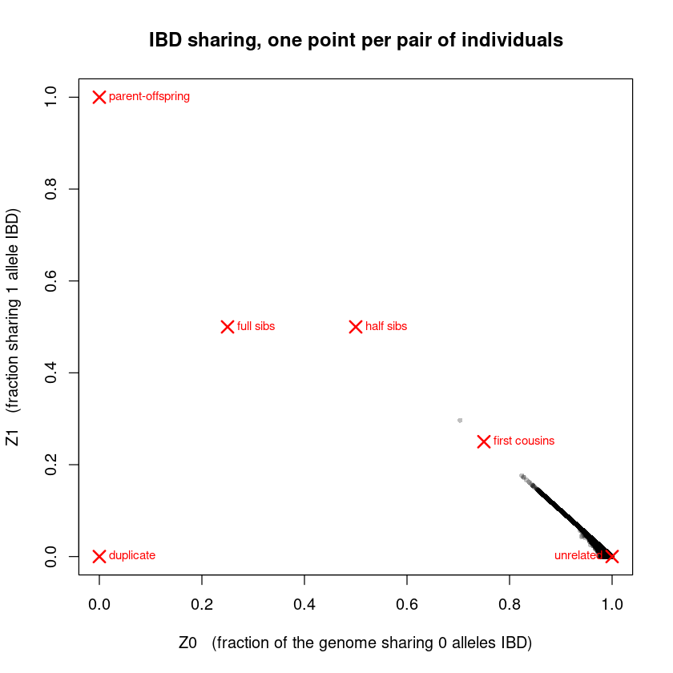

**Questions**

- What is the largest PI_HAT in this cohort, and would you call that pair related?
- Some pairs are `nan`. Which individuals are involved, and what do they have in common?

And the distribution of `PI_HAT` itself. The dashed lines mark first-degree (0.5), second-degree (0.25) and third-degree (0.125) relatives.

```
setwd(path.expand("~/relatedness_human"))

hist(g$PI_HAT[ok], breaks = 60, col = "steelblue", border = "white",
     xlim = c(0, 1),
     xlab = "PI_HAT", ylab = "number of pairs",
     main = "Relatedness across all pairs")
abline(v = c(0.5, 0.25, 0.125), col = "red", lty = 2)
text(c(0.5, 0.25, 0.125), par("usr")[4]*0.8,
     c("1st degree", "2nd", "3rd"), col = "red", pos = 4, cex = 0.8)

cat("largest PI_HAT in the data:", max(g$PI_HAT, na.rm = TRUE), "\n\n")
cat("pairs above each threshold:\n")
for (t in c(0.5, 0.25, 0.125, 0.08)) {
    cat(sprintf("  PI_HAT > %.3f : %d pairs\n", t, sum(g$PI_HAT > t, na.rm = TRUE)))
}
```

```
largest PI_HAT in the data: 0.1483

pairs above each threshold:
  PI_HAT > 0.500 : 0 pairs
  PI_HAT > 0.250 : 0 pairs
  PI_HAT > 0.125 : 1 pairs
  PI_HAT > 0.080 : 7 pairs
```

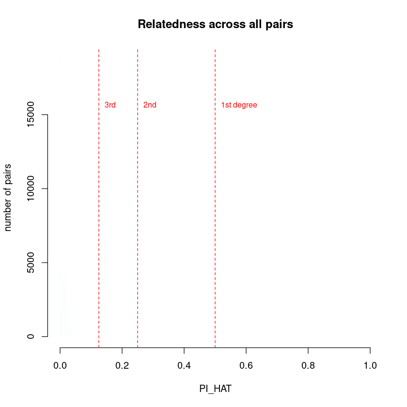

**Questions**

- Where do almost all the pairs sit in the Z0/Z1 plot, and which relationship is that?
- What is the largest `PI_HAT`? Is there **any** pair you would call first- or second-degree relatives?
- Given the answer, was it safe to run a GWAS on this cohort without removing anyone for relatedness?
- The histogram is not centred on exactly zero. Why would unrelated pairs still show a little bit of apparent sharing?

## 4. The pairs that came out as NaN

The plot above quietly dropped some pairs, because PLINK could not estimate them and wrote `nan`. That is worth chasing rather than ignoring - it is telling us something about the data.

```
source ~/relatedness_human/env.sh

echo "--- how many pairs failed? ---"
awk 'NR>1 && $10=="nan"' gwa_ibd.genome | wc -l

echo
echo "--- which individuals are involved? ---"
# NB: in this fileset the informative label is the FID (column 1 / 3);
# the IID is just "1" for everybody
awk 'NR>1 && $10=="nan" {print $1; print $3}' gwa_ibd.genome | sort -u
```

```
--- how many pairs failed? ---
54

--- which individuals are involved? ---
case101
case103
case107
case110
case111
case151
case152
case153
case154
case155
case156
case30
case66
case84
case97
```

A pair can only fail if there is too little data. Let us measure how much genotype data each individual actually has, with `--missing`.

```
source ~/relatedness_human/env.sh

plink --bfile $DATA/gwa --missing --out gwa_miss > /dev/null 2>&1

echo "--- the per-individual missingness file ---"
head -n 1 gwa_miss.imiss

echo
echo "--- the 10 individuals with the most missing data (F_MISS = fraction missing) ---"
awk 'NR>1 {print $6"\t"$1}' gwa_miss.imiss | sort -gr | head -n 10

echo
echo "--- how many individuals are missing more than 20% of their genotypes? ---"
awk 'NR>1 && $6>0.2' gwa_miss.imiss | wc -l
```

```
--- the per-individual missingness file ---
       FID  IID MISS_PHENO   N_MISS   N_GENO   F_MISS

--- the 10 individuals with the most missing data (F_MISS = fraction missing) ---
0.5527	case101
0.5479	case110
0.546	case107
0.5458	case103
0.5405	case84
0.5352	case97
0.5285	case66
0.527	case111
0.5263	case30
0.5128	case156

--- how many individuals are missing more than 20% of their genotypes? ---
15
```

```
setwd(path.expand("~/relatedness_human"))

m <- read.table("gwa_miss.imiss", header = TRUE)
m <- m[order(-m$F_MISS), ]

plot(m$F_MISS, pch = 16, cex = 0.8,
     col = ifelse(m$F_MISS > 0.2, "red", "grey40"),
     xlab = "individual, sorted by missingness",
     ylab = "fraction of genotypes missing",
     main = "How much data does each individual have?")
abline(h = 0.2, lty = 2)
legend("topright", c("more than 20% missing", "kept"),
       pch = 16, col = c("red", "grey40"), bty = "n")

cat("individuals above 20% missing:", sum(m$F_MISS > 0.2), "\n")
```

```
individuals above 20% missing: 15
```

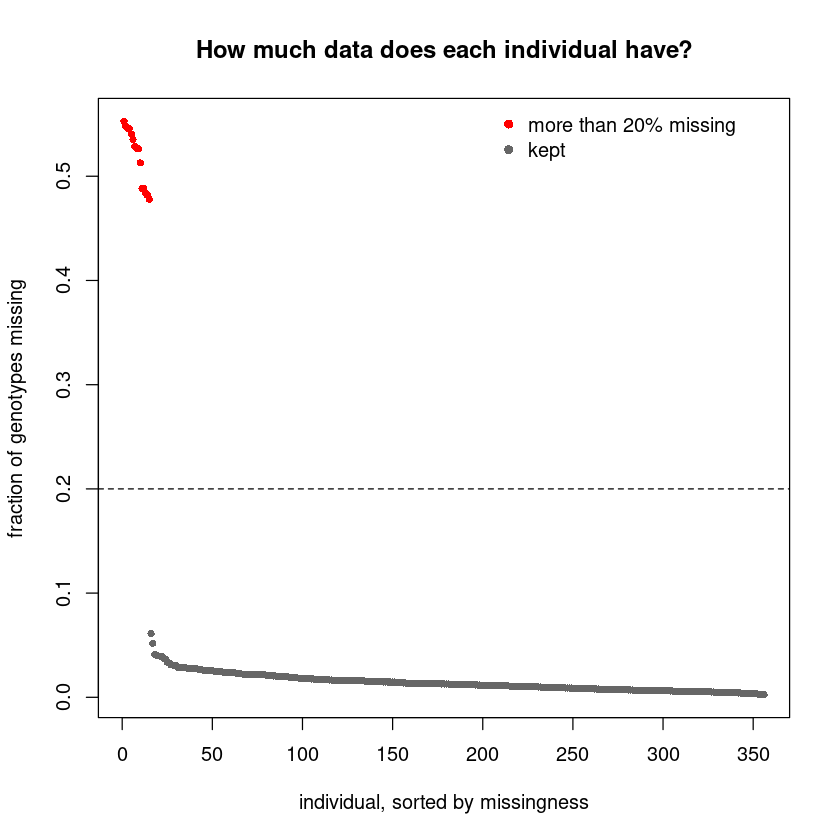

**Questions**

- Compare the red individuals with the list of individuals in the failed pairs. Are they the same people?
- Roughly what fraction of their genotypes are those individuals missing?
- Why does that make the IBD estimate impossible for a **pair** of them? (think about how many SNPs are left where *both* members of the pair have a genotype)

## 5. Redo it on the individuals with enough data

`--mind 0.2` drops individuals missing more than 20% of their genotypes, before anything else runs.

```
source ~/relatedness_human/env.sh
# ~1-2 min

plink --bfile $DATA/gwa --genome --autosome --maf 0.05 --mind 0.2 --out gwa_ibd_clean

echo
echo "--- how many pairs failed this time? ---"
awk 'NR>1 && $10=="nan"' gwa_ibd_clean.genome | wc -l
```

```
PLINK v1.90b6 64-bit (26 May 2018)             www.cog-genomics.org/plink/1.9/
(C) 2005-2018 Shaun Purcell, Christopher Chang   GNU General Public License v3
Logging to gwa_ibd_clean.log.
Options in effect:
  --autosome
  --bfile /course/data/current_data/gwas_human/gwa
  --genome
  --maf 0.05
  --mind 0.2
  --out gwa_ibd_clean

386830 MB RAM detected; reserving 193415 MB for main workspace.
488756 out of 499264 variants loaded from .bim file.
356 people (145 males, 211 females) loaded from .fam.
356 phenotype values loaded from .fam.
15 people removed due to missing genotype data (--mind).
IDs written to gwa_ibd_clean.irem .
Using up to 87 threads (change this with --threads).
Before main variant filters, 341 founders and 0 nonfounders present.
Calculating allele frequencies... 0%1%2%3%4%5%6%7%8%9%10%11%12%13%14%15%16%17%18%19%20%21%22%23%24%25%26%27%28%29%30%31%32%33%34%35%36%37%38%39%40%41%42%43%44%45%46%47%48%49%50%51%52%53%54%55%56%57%58%59%60%61%62%63%64%65%66%67%68%69%70%71%72%73%74%75%76%77%78%79%80%81%82%83%84%85%86%87%88%89%90%91%…
Total genotyping rate in remaining samples is 0.985758.
111575 variants removed due to minor allele threshold(s)
(--maf/--max-maf/--mac/--max-mac).
377181 variants and 341 people pass filters and QC.
Among remaining phenotypes, 141 are cases and 200 are controls.
IBD calculations complete.
Finished writing gwa_ibd_clean.genome .

--- how many pairs failed this time? ---
0
```

```
setwd(path.expand("~/relatedness_human"))

gc2 <- read.table("gwa_ibd_clean.genome", header = TRUE)

cat("before  --mind 0.2 :", nrow(g),   "pairs,", sum(is.na(g$PI_HAT)),   "NaN\n")
cat("after   --mind 0.2 :", nrow(gc2), "pairs,", sum(is.na(gc2$PI_HAT)), "NaN\n\n")
cat("largest PI_HAT before:", max(g$PI_HAT,   na.rm = TRUE), "\n")
cat("largest PI_HAT after: ", max(gc2$PI_HAT, na.rm = TRUE), "\n")

par(mfrow = c(1, 2))
hist(g$PI_HAT[ok], breaks = 60, col = "grey70", border = "white",
     xlab = "PI_HAT", main = "all individuals")
hist(gc2$PI_HAT, breaks = 60, col = "steelblue", border = "white",
     xlab = "PI_HAT", main = "missingness > 20% removed")
par(mfrow = c(1, 1))
```

```
before  --mind 0.2 : 63190 pairs, 54 NaN
after   --mind 0.2 : 57970 pairs, 0 NaN

largest PI_HAT before: 0.1483
largest PI_HAT after:  0.1483
```

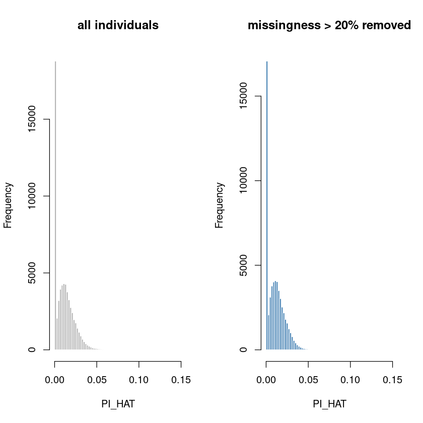

**Questions**

- Did removing those individuals change the conclusion about relatedness in this cohort?
- The number of pairs dropped a lot. Why does removing 15 individuals remove so many pairs?
- In a real study, would you drop those individuals, or try to get better data for them?

### And finally, back to the assumption

The note at the top said this estimator assumes a single homogeneous population.

- If this cohort had actually been a mix of, say, European and East Asian individuals, what would the Z0/Z1 plot have looked like, and which pairs would have been wrongly flagged as relatives?
- Relatedness and population structure are two different problems that produce a similar symptom in a GWAS. How would you tell them apart?

### Run the cell below to take the quiz

```
from jupyterquiz import display_quiz

display_quiz("https://raw.githubusercontent.com/popgenDK/courses/main/current_exercises/relatedness_diversity/quiz/relatedness_human.json")
```